# Midpoint Delieverable - Learning Chinese

Language Lovers Team

## Introduction

Given China’s increasingly important role on the global stage, more and more Americans are considering learning Chinese as a second language. As a group, we were interested in examining how this trend has grown over the past few decades, and what conclusions can be drawn from its growth.

We made our conclusions based on data gathered by a series of 25 surveys conducted by the MLA (Modern Language Association) between 1958 and 2016.

These surveys collected detailed enrollment information on foriegn languages from colleges across the US. The data is extensive, containing 208,020 observations and 24 features. The collection of the data was primarily funded by the United States Department of Education, with additional funding from several other institutions.

After reviewing the data, we had three main questions:

1. Where in the US are students studying Chinese?
2. How popular of a language is Chinese compared to other foriegn languages currently?
3. How does the growth of enrollment in Chinese compare to other foreign languages?

In the following sections, we provide charts to answer the above questions, as well as summarize the important points of the data in a table.

## Summary Information

In terms of percentages, **1.82%** of people learning a language was learning Chinese and in 2016, the percentage is **3.7%** . Out of the total number of students learning Chinese, **23.63%** have been from California and in 2016 alone, **18.97%** of students studied Chinese in California

The school with the most students who learned Chinese in 2016 is **NEW YORK U** and from all terms, however, the school who had has the most number of students learning Chinese is **CITY C OF SAN FRANCISCO**.

From the data, we can predict that some historic events, such as the gold rush, has lead to not only the increase in Chinese immagrants, but also an increase of the number of Chinese learners in those areas.

## Summary table

This table shows the total number of language learners in U.S. Colleges by states in 2016, and the number and percentages of Chinese learners. It is arranged by descending order of the percentage of Chinese learners to show the relative popularity of Chinese to language learners studying in U.S. Colleges.

| State | Total Chinese Learners | Total Language Learners | Percent Chinese Learners |
| --- | --- | --- | --- |
| VT | 877 | 9807 | 8.2 |
| MA | 3245 | 45498 | 6.7 |
| RI | 620 | 10100 | 5.8 |
| NH | 330 | 5576 | 5.6 |
| CA | 11308 | 203192 | 5.3 |
| ME | 216 | 4144 | 5.0 |
| WA | 1299 | 26222 | 4.7 |
| NY | 6543 | 143014 | 4.4 |
| CT | 841 | 18696 | 4.3 |
| NJ | 1701 | 37607 | 4.3 |
| NV | 437 | 9963 | 4.2 |
| ID | 414 | 9897 | 4.0 |
| PA | 2906 | 71950 | 3.9 |
| CO | 875 | 22359 | 3.8 |
| MD | 1094 | 28479 | 3.7 |
| MN | 1008 | 27172 | 3.6 |
| GA | 1924 | 52666 | 3.5 |
| DC | 756 | 21328 | 3.4 |
| IA | 614 | 17369 | 3.4 |
| VA | 1677 | 47786 | 3.4 |
| OH | 2133 | 62012 | 3.3 |
| UT | 664 | 20597 | 3.1 |
| OR | 765 | 24734 | 3.0 |
| AZ | 1040 | 35338 | 2.9 |
| WI | 832 | 27407 | 2.9 |
| IL | 1291 | 44340 | 2.8 |
| MI | 1252 | 43723 | 2.8 |
| AK | 60 | 2150 | 2.7 |
| DE | 161 | 5786 | 2.7 |
| KY | 507 | 18615 | 2.7 |
| NC | 1856 | 66976 | 2.7 |
| HI | 252 | 9430 | 2.6 |
| IN | 1142 | 46394 | 2.4 |
| MO | 845 | 33947 | 2.4 |
| TX | 2583 | 108736 | 2.3 |
| AR | 239 | 11337 | 2.1 |
| FL | 1439 | 68629 | 2.1 |
| MS | 313 | 14661 | 2.1 |
| SC | 682 | 32392 | 2.1 |
| WV | 146 | 6676 | 2.1 |
| MT | 76 | 3677 | 2.0 |
| ND | 44 | 2111 | 2.0 |
| AL | 313 | 16185 | 1.9 |
| WY | 49 | 2506 | 1.9 |
| KS | 191 | 11203 | 1.7 |
| OK | 262 | 15053 | 1.7 |
| TN | 436 | 28967 | 1.5 |
| LA | 229 | 18091 | 1.2 |
| NM | 140 | 13695 | 1.0 |
| NE | 60 | 8099 | 0.7 |

From the table, we can see Vermont has the largest percentage of Chinese learners, but California has the greatest number of Chinese learners. Therefore, we need to consider both the percentage and the actual number when determining the popularity of Chinese among language learners in U.S. Colleges.

## Charts

### Map

Below includes multiple maps of the numbers of Chinese learners in higher institution across the United States. This chart intends to show the relationship between the **popularity of Chinese learning in different states** in 2016.

From the first graph of the full United States, we can see that **California** has the most amount of Chinese learners, much higher than all other states.

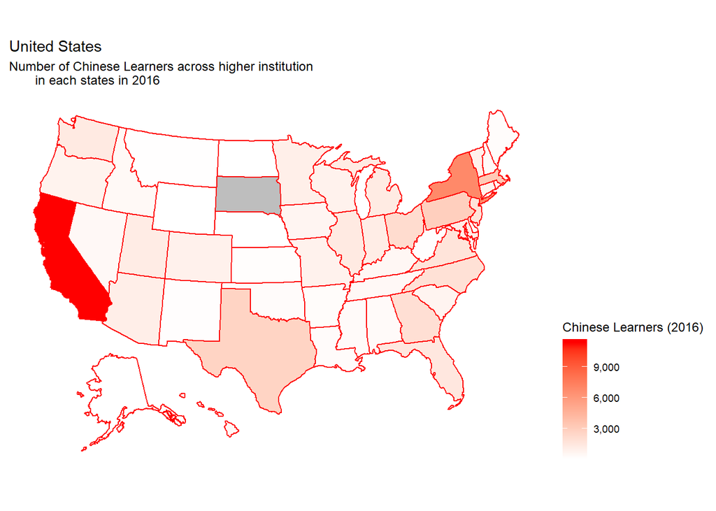

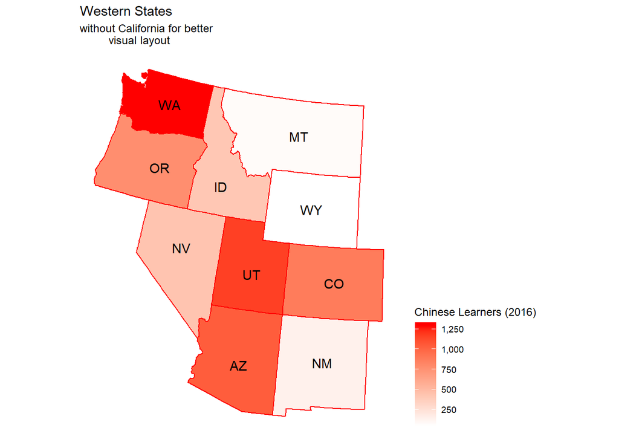

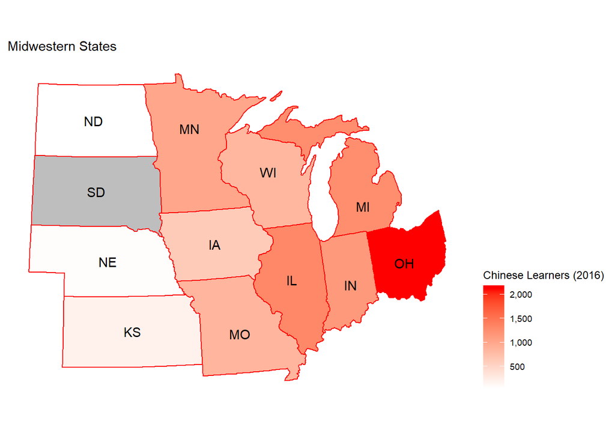

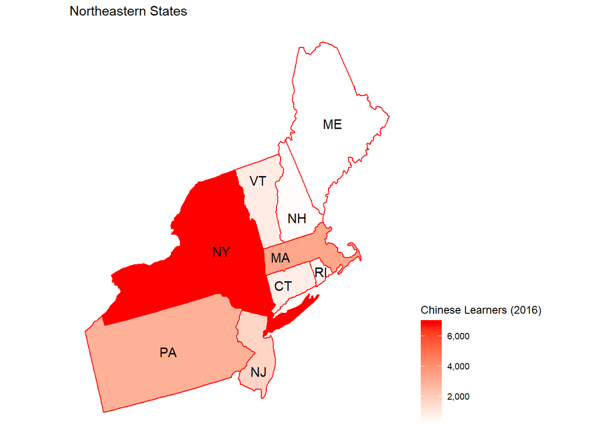

[figure not shown]

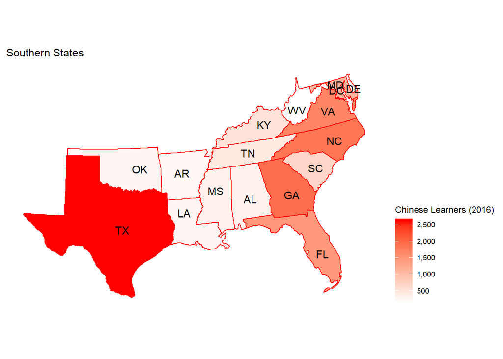

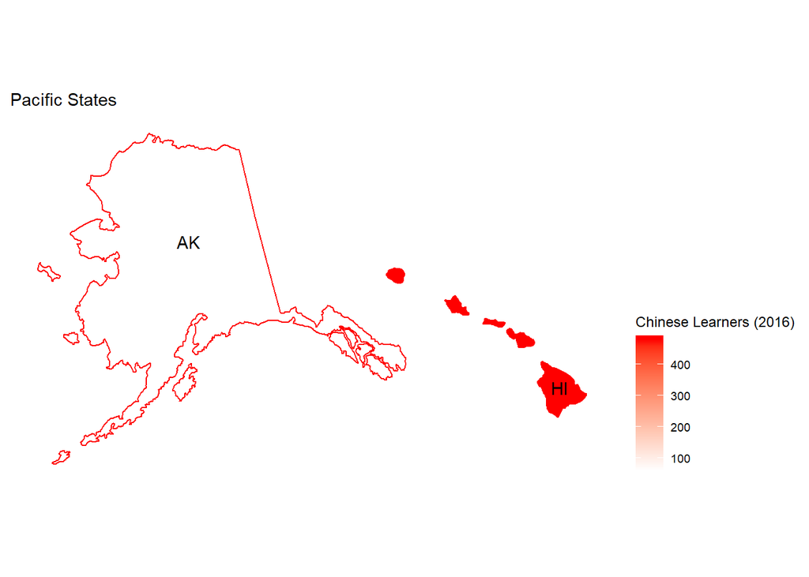

### Bar Chart

This bar chart shows the **popularity of all second languages learnt** by U.S. college students in 2016. Chinese Language is the seventh most popular language among all of them and the second most popular Asian language. However, there is still a big gap between the number of Chinese learners and that of the most popular language, Spanish, as the number of Spanish learners is more than 800,000, but that of Chinese learners is less than 100,000.

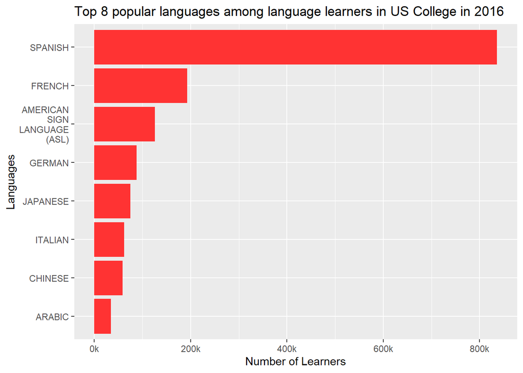

Among the top 8 languages, only 2 of them are Asian languages. We can conclude that in general, Asian languages are less attractive to U.S. students.

### Line Graph

The graphs below represent the **change in popularity of Chinese** at US colleges over the past few decades, as well as the change in popularity of chinese relative to other popular languages.

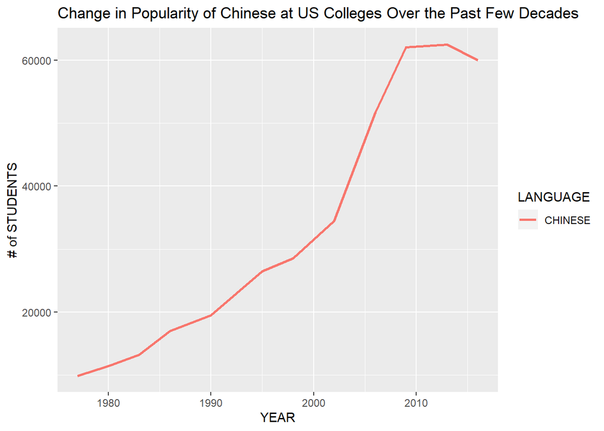

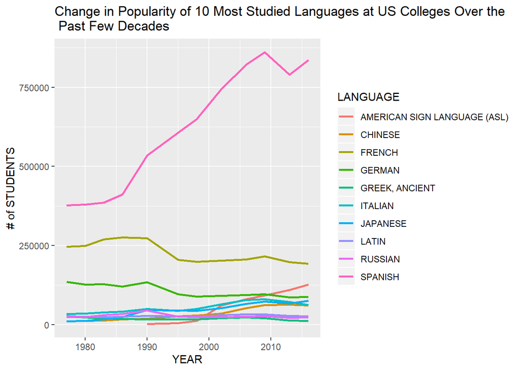